# Investigating the Prosper Loan Data by Anton Rubisov

# Final Plots and Summary

### Plot One

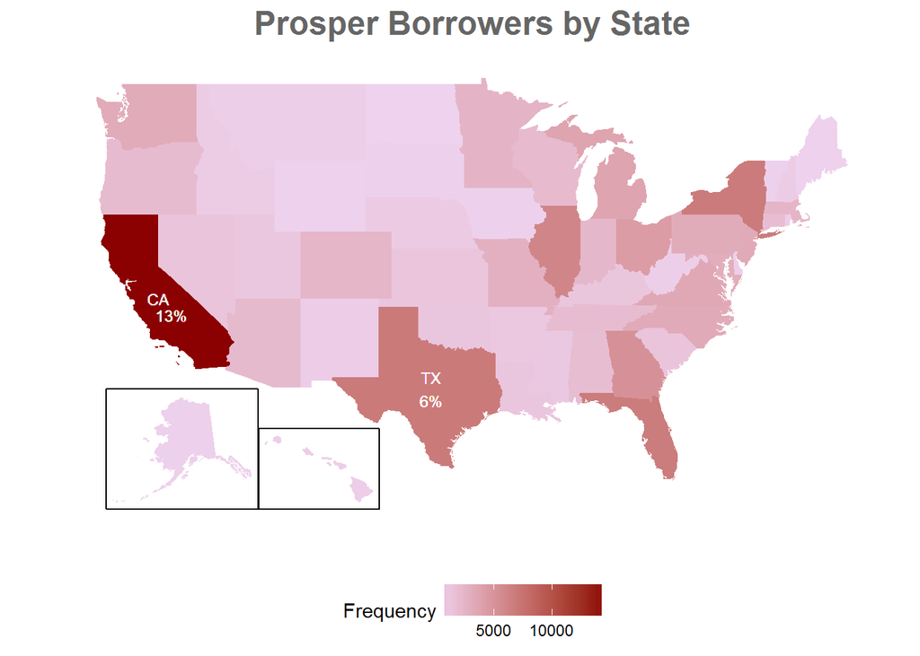

### Plot Two

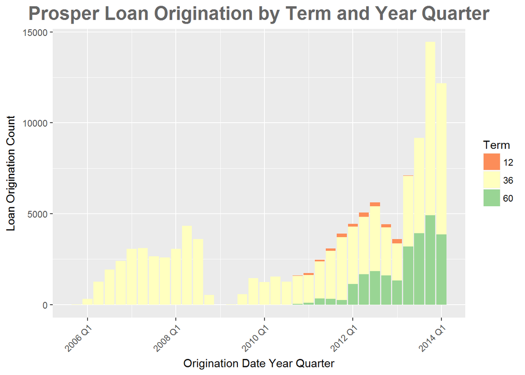

### Description Two

The lull in 2009 is the Prosper ‘quiet period’ prior to registration with the SEC. In late 2010, 1y term loans were introduced, as the platform was gaining popularity. 1y loans were cancelled in 2013, which correlated strongly with a surge in loan originations in 3y and 5y terms, though disproportionately. I would opine that while the cancellation of the 1y loans did play a factor in increasing origination of the other terms, it is more likely that the increase is explained by an increasing popularity in the platform.

### Plot Three

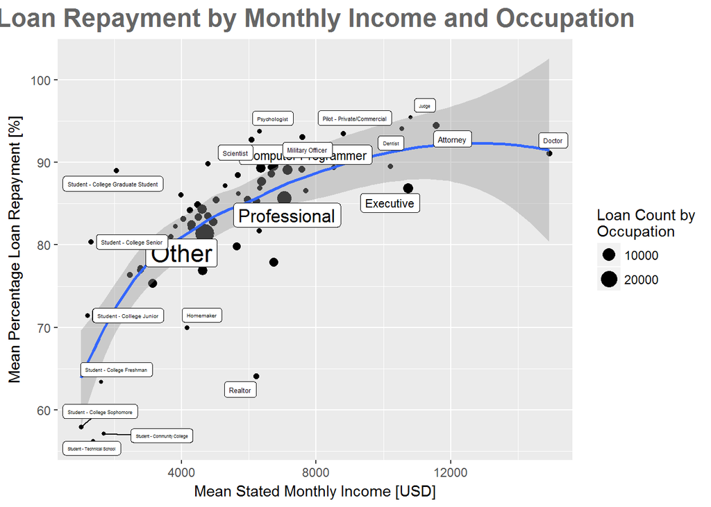

### Description Three

This plot looks at the percentage timely loan repayments versus mean stated monthly income, grouped by the borrowers’ occupations. To assess loan repayment, each loan is given a binary value of either ‘good’ or ‘bad’, where the ‘bad’ loans are those that were either cancelled, charged off, defaulted, or past due, and loans are ‘good’ otherwise.

The plot exhibits a highly expected trend of increased loan repayment with increasing monthly income, driven of course by the expectation that as ones income is higher and more reliably, they are better able to make principal and interest payments. Notably, the majority of occupations fall within the 80-90% timely repayment range.

# Reflection

As a newcomer to R, there was a substantial learning curve for getting up to speed with the syntax and API. I was happy to find that the vast majority of what I wanted to achieve was covered by the help function, package documentation, and stackoverflow answers - the community support for the language is clearly high.

While the Prosper Loan data is by no means huge, at under 100 MB, the number of variables did make it tricky to work with. The data came rather clean, with no work having to be done to understand column names, or transform them into usable format (with the single exception of state names being in a case different from that provided by the R “state” dataframe). Unlike with ‘mtcars’ or ‘diamonds’, the number of variables made it not-obvious which variables were of interest or worth exploring. My approach was to begin with a few and incorporate more as it became needed, and I regret taking this approach. In the future, I’d like to first go through and highlight all variables I want to explore *before* diving in, as this led to tunnel vision and ultimately not touching on some of the ones that I later realized would be of interest.

The dplyr package, though I avoided it at first, is very useful and very powerful, as it allowed me to create new derived variables with great ease. ggplot, surprisingly enough, became intuitive by the end of the analysis. Overplotting was a major problem at times, but adding just one or two layers to ggplot made this easily rectifiable.

My single biggest takeaway is to work with data that I find inherently interesting, and to ask questions rather than to explore blindly. The exploratory data analysis can quickly become a chore if the exploration being done, or results being gleaned, are of no personal interest to the explorer. Conversely, understanding what questions I want to ask of the data, and having a personal interest in understanding the answers, makes it not feel like work.

# Links Used

https://en.wikipedia.org/wiki/Prosper_Marketplace

https://gist.github.com/cdesante/4252133

https://cran.r-project.org/web/packages/fiftystater/vignettes/fiftystater.html

http://stackoverflow.com/questions/24247285/combine-facet-wrap-of-line-plot1st-dataset-with-facet-wrap-of-point-plot2nd-d

https://jasonicarter.github.io/Prosper-EDA-R/

https://rpubs.com/grace-pehl/prosper

http://rpubs.com/dksmith01/analysis-prosper-lending-data

https://rstudio-pubs-static.s3.amazonaws.com/68611_df00687bfcf94145ab29659d62ca07dd.html

http://stackoverflow.com/questions/21571703/format-date-as-year-quarter

https://briatte.github.io/ggcorr/#controlling-the-coefficient-labels